# 10-optimise_kol

This file documents some experiments of optimising more complex indices i.e. `kol` and `kol_cdf`. The creation of these indices can be found in `7-new_index.Rmd` and `pp-optim/Meeting4_15-23-20.html`. My experiment shows that

- A combination of`serach_better` and `search_polish` works better for more complex indices
- `kol_cdf` tends to have more stable range in the index_val than `kol`.

## 1. `kol` index with `search_geodesic` without polishing

With a geodesic search, the optimisation fails to find a basis near the theoretical best basis: `matrix(c(0, 1, 0, 0, 0))` and the distance is quite large (a normal proj_dist between the final basis and the theoretical basis is around point something). Also the change in the index_val is drastic: see the `calc_kol` result for `basis_0` and `last_one[[1]]`. This provides two insights:

- `search_geodesic` is not an optimal solution for more complex indices
- `kol` index, on itself, is not a stable index - pre-processing step like scaling or normalisation will be needed for it to produce better result.

```r
set.seed(123456)
kol_geodesic <- tourr::animate_dist(data, tour_path = guided_tour(kol(), d = 1,
                                                          search_f = search_geodesic_latest),
                                             rescale = FALSE, polish = FALSE)
```

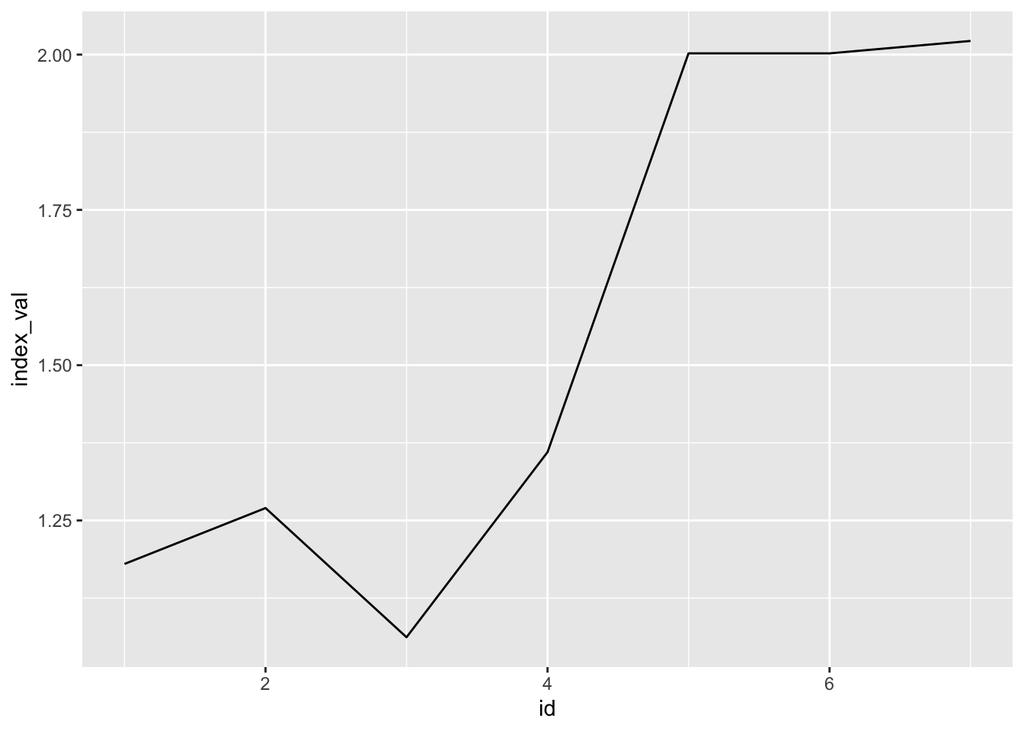

```r
last_one <- kol_geodesic %>% filter(info == "interpolation") %>% pull(basis) %>% tail(1)

kol_geodesic %>% filter(info == "interpolation") %>% mutate(id = row_number())  %>%
  ggplot(aes(x = id, y = index_val)) + geom_line()
```

```r
basis_0 <- matrix(c(0, 1, 0, 0, 0))
calc_kol(basis_0, data = data)
```

```
## [1] 89.596
```

```r
calc_kol(last_one[[1]], data = data)
```

```
## [1] 3.272
```

```r
tourr::proj_dist(last_one[[1]], basis_0)
```

```
## [1] 1.39814
```

## 2. `kol()` index with `serach_better` without polishing

```r
set.seed(123456)
kol_better <- tourr::animate_dist(data, tour_path = guided_tour(kol(), d = 1,
                                                          search_f = search_better),
                            rescale = FALSE, polish = FALSE)
```

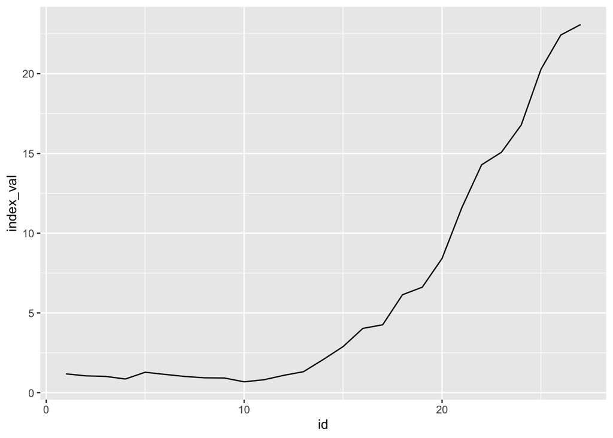

```r
last_one <- kol_better %>% filter(info == "interpolation") %>% pull(basis) %>% tail(1)
kol_better %>% filter(info == "interpolation") %>% mutate(id = row_number())  %>%
  ggplot(aes(x = id, y = index_val)) + geom_line()
```

```r
basis_0 <- matrix(c(0, 1, 0, 0, 0))
calc_kol(basis_0, data = data)
```

```
## [1] 89.596
```

```r
calc_kol(last_one[[1]], data = data)
```

```
## [1] 39.45
```

## 3.`kol_cdf()` with `search_better` without polishing

As mentioned before `kol` index is not stable, `kol_cdf` is a much steady index based on the `ks.test`. This time, the index_val is restricted in a smaller region between 0 and 1.

```r
set.seed(123456)
kol_cdf_better <- tourr::animate_dist(data, tour_path = guided_tour(kol_cdf(), d = 1,
                                                                 search_f = search_better),
                                   rescale = FALSE, polish = FALSE)
```

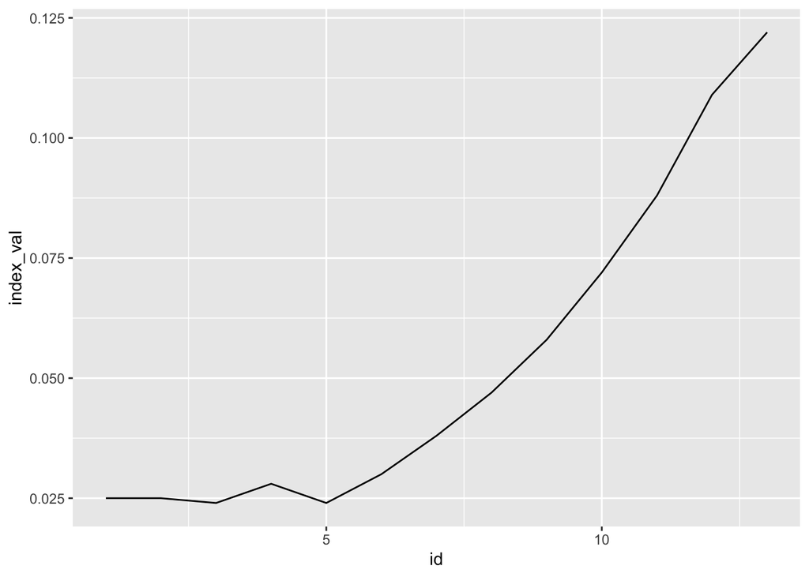

```r
last_one <- kol_cdf_better %>% filter(info == "interpolation") %>% pull(basis) %>% tail(1)
first_one <- kol_cdf_better %>% filter(info == "interpolation") %>% pull(basis) %>% head(1)
kol_cdf_better %>% filter(info == "interpolation") %>% mutate(id = row_number())  %>%
  ggplot(aes(x = id, y = index_val)) + geom_line()
```

```r
basis_0 <- matrix(c(0, 1, 0, 0, 0))
calc_kol_cdf(basis_0, data = data)
```

```
## [1] 0.182
```

```r
calc_kol_cdf(last_one[[1]], data = data)
```

```
## [1] 0.122
```

```r
calc_kol_cdf(first_one[[1]], data = data)
```

```
## [1] 0.025
```

## 4. `kol_cdf()` with `search_better` with polishing

Withe polishing step, the optimisation keeps on finding the basis with higher index value and it is getting closer to the index_val of the theoretical best.

```r
set.seed(123456)
kol_cdf_better_polish <- tourr::animate_dist(data, tour_path = guided_tour(kol_cdf(), d = 1,
                                                                     search_f = search_better),
                                       rescale = FALSE, polish = TRUE)
```

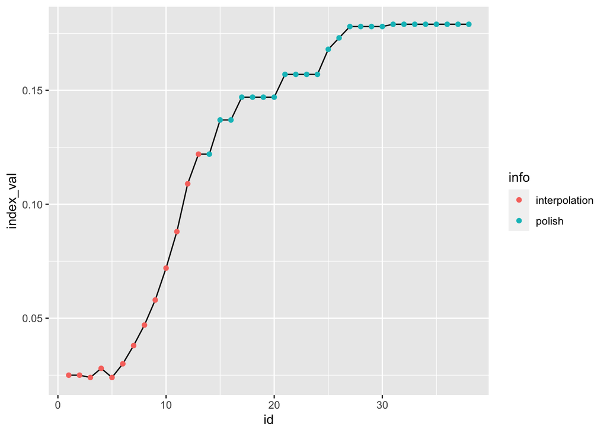

```r
kol_cdf_better_polish$record %>% filter(info %in% c("interpolation", "polish")) %>% mutate(id = row_number())  %>%
  ggplot(aes(x = id, y = index_val)) + geom_line() + geom_point(aes(col = info))
```